Student : Esteban Ordenes

Post Graduate Program in Data Science and Business Analytics

PGP-DSBA-UTA-Dec20-A

# Travel Package Purchase Prediction

## Context

Currently, there are 5 types of packages the company is offering - Basic, Standard, Deluxe, Super Deluxe, King. Looking at the data of the last year, we observed that 18% of the customers purchased the packages.

However, the marketing cost was quite high because customers were contacted at random without looking at the available information.

The company is now planning to launch a new product i.e. Wellness Tourism Package. Wellness Tourism is defined as Travel that allows the traveler to maintain, enhance or kick-start a healthy lifestyle, and support or increase one's sense of well-being.

However, this time company wants to harness the available data of existing and potential customers to make the marketing expenditure more efficient.

## Objective

Predict which customer is more likely to purchase the newly introduced travel package.

## Data Dictionary

- CustomerID: Unique customer ID
- ProdTaken: Whether the customer has purchased a package or not (0: No, 1: Yes)
- Age: Age of customer
- TypeofContact: How customer was contacted (Company Invited or Self Inquiry)
- CityTier: City tier depends on the development of a city, population, facilities, and living standards. The categories are ordered i.e. Tier 1 > Tier 2 > Tier 3
- Occupation: Occupation of customer
- Gender: Gender of customer
- NumberOfPersonVisiting: Total number of persons planning to take the trip with the customer
- PreferredPropertyStar: Preferred hotel property rating by customer
- MaritalStatus: Marital status of customer
- NumberOfTrips: Average number of trips in a year by customer
- Passport: The customer has a passport or not (0: No, 1: Yes)
- OwnCar: Whether the customers own a car or not (0: No, 1: Yes)
- NumberOfChildrenVisiting: Total number of children with age less than 5 planning to take the trip with the customer
- Designation: Designation of the customer in the current organization
- MonthlyIncome: Gross monthly income of the customer

## Customer interaction data:

- PitchSatisfactionScore: Sales pitch satisfaction score
- ProductPitched: Product pitched by the salesperson
- NumberOfFollowups: Total number of follow-ups has been done by the salesperson after the sales pitch
- DurationOfPitch: Duration of the pitch by a salesperson to the customer

### Loading libraries

```python
import warnings
warnings.filterwarnings("ignore")

# Libraries to help with reading and manipulating data

import pandas as pd
import numpy as np
import scipy.stats as stats

# libaries to help with data visualization
import matplotlib.pyplot as plt
import seaborn as sns

# Library to split data
from sklearn.model_selection import train_test_split

#libraries to help with model building
from sklearn.tree import DecisionTreeClassifier
from sklearn import tree



# Removes the limit from the number of displayed columns and rows.
# This is so I can see the entire dataframe when I  print it
pd.set_option("display.max_columns", None)
# pd.set_option('display.max_rows', None)
pd.set_option("display.max_rows", 200)

# To build linear model for statistical analysis and prediction
import statsmodels.stats.api as sms
from statsmodels.stats.outliers_influence import variance_inflation_factor
import statsmodels.api as sm
from statsmodels.tools.tools import add_constant

# To get diferent metric scores
from sklearn import metrics
from sklearn.metrics import confusion_matrix, classification_report
from sklearn.metrics import accuracy_score, recall_score, precision_score, roc_auc_score, roc_curve, confusion_matrix, precision_recall_curve, f1_score

from sklearn.model_selection import GridSearchCV
from sklearn.model_selection import train_test_split

# For pandas profiling
#from pandas_profiling import ProfileReport

from sklearn import tree
from sklearn.tree import DecisionTreeClassifier
from sklearn.ensemble import RandomForestClassifier
from sklearn.ensemble import BaggingClassifier
from sklearn.ensemble import GradientBoostingRegressor, AdaBoostRegressor, StackingRegressor
from sklearn.ensemble import AdaBoostClassifier, GradientBoostingClassifier
from xgboost import XGBClassifier



import warnings
warnings.filterwarnings('ignore')
```

### Read the dataset

```python
Loan = pd.read_csv("Tourism.csv")
```

```python
# copying data to another variable to avoid any changes to original data
data = Loan.copy()
```

### View the first and last 5 rows of the dataset.

```python
data.head()
```

|  | CustomerID | ProdTaken | Age | TypeofContact | CityTier | DurationOfPitch | Occupation | Gender | NumberOfPersonVisiting | NumberOfFollowups | ProductPitched | PreferredPropertyStar | MaritalStatus | NumberOfTrips | Passport | PitchSatisfactionScore | OwnCar | NumberOfChildrenVisiting | Designation | MonthlyIncome |
| --- | --- | --- | --- | --- | --- | --- | --- | --- | --- | --- | --- | --- | --- | --- | --- | --- | --- | --- | --- | --- |
| 0 | 200000 | 1 | 41.0 | Self Enquiry | 3 | 6.0 | Salaried | Female | 3 | 3.0 | Deluxe | 3.0 | Single | 1.0 | 1 | 2 | 1 | 0.0 | Manager | 20993.0 |
| 1 | 200001 | 0 | 49.0 | Company Invited | 1 | 14.0 | Salaried | Male | 3 | 4.0 | Deluxe | 4.0 | Divorced | 2.0 | 0 | 3 | 1 | 2.0 | Manager | 20130.0 |
| 2 | 200002 | 1 | 37.0 | Self Enquiry | 1 | 8.0 | Free Lancer | Male | 3 | 4.0 | Basic | 3.0 | Single | 7.0 | 1 | 3 | 0 | 0.0 | Executive | 17090.0 |
| 3 | 200003 | 0 | 33.0 | Company Invited | 1 | 9.0 | Salaried | Female | 2 | 3.0 | Basic | 3.0 | Divorced | 2.0 | 1 | 5 | 1 | 1.0 | Executive | 17909.0 |
| 4 | 200004 | 0 | NaN | Self Enquiry | 1 | 8.0 | Small Business | Male | 2 | 3.0 | Basic | 4.0 | Divorced | 1.0 | 0 | 5 | 1 | 0.0 | Executive | 18468.0 |

```python
data.tail()
```

|  | CustomerID | ProdTaken | Age | TypeofContact | CityTier | DurationOfPitch | Occupation | Gender | NumberOfPersonVisiting | NumberOfFollowups | ProductPitched | PreferredPropertyStar | MaritalStatus | NumberOfTrips | Passport | PitchSatisfactionScore | OwnCar | NumberOfChildrenVisiting | Designation | MonthlyIncome |
| --- | --- | --- | --- | --- | --- | --- | --- | --- | --- | --- | --- | --- | --- | --- | --- | --- | --- | --- | --- | --- |
| 4883 | 204883 | 1 | 49.0 | Self Enquiry | 3 | 9.0 | Small Business | Male | 3 | 5.0 | Deluxe | 4.0 | Unmarried | 2.0 | 1 | 1 | 1 | 1.0 | Manager | 26576.0 |
| 4884 | 204884 | 1 | 28.0 | Company Invited | 1 | 31.0 | Salaried | Male | 4 | 5.0 | Basic | 3.0 | Single | 3.0 | 1 | 3 | 1 | 2.0 | Executive | 21212.0 |
| 4885 | 204885 | 1 | 52.0 | Self Enquiry | 3 | 17.0 | Salaried | Female | 4 | 4.0 | Standard | 4.0 | Married | 7.0 | 0 | 1 | 1 | 3.0 | Senior Manager | 31820.0 |
| 4886 | 204886 | 1 | 19.0 | Self Enquiry | 3 | 16.0 | Small Business | Male | 3 | 4.0 | Basic | 3.0 | Single | 3.0 | 0 | 5 | 0 | 2.0 | Executive | 20289.0 |
| 4887 | 204887 | 1 | 36.0 | Self Enquiry | 1 | 14.0 | Salaried | Male | 4 | 4.0 | Basic | 4.0 | Unmarried | 3.0 | 1 | 3 | 1 | 2.0 | Executive | 24041.0 |

### Understand the shape of the dataset.

```python
data.shape
```

```
(4888, 20)
```

- The dataset has 4888 rows and 20 columns

### Check data types and number of non-null values for each column.

```python
data.info()
```

```
<class 'pandas.core.frame.DataFrame'>
RangeIndex: 4888 entries, 0 to 4887
Data columns (total 20 columns):
 #   Column                    Non-Null Count  Dtype
---  ------                    --------------  -----
 0   CustomerID                4888 non-null   int64
 1   ProdTaken                 4888 non-null   int64
 2   Age                       4662 non-null   float64
 3   TypeofContact             4863 non-null   object
 4   CityTier                  4888 non-null   int64
 5   DurationOfPitch           4637 non-null   float64
 6   Occupation                4888 non-null   object
 7   Gender                    4888 non-null   object
 8   NumberOfPersonVisiting    4888 non-null   int64
 9   NumberOfFollowups         4843 non-null   float64
 10  ProductPitched            4888 non-null   object
 11  PreferredPropertyStar     4862 non-null   float64
 12  MaritalStatus             4888 non-null   object
 13  NumberOfTrips             4748 non-null   float64
 14  Passport                  4888 non-null   int64
 15  PitchSatisfactionScore    4888 non-null   int64
 16  OwnCar                    4888 non-null   int64
 17  NumberOfChildrenVisiting  4822 non-null   float64
 18  Designation               4888 non-null   object
 19  MonthlyIncome             4655 non-null   float64
dtypes: float64(7), int64(7), object(6)
memory usage: 763.9+ KB
```

- We can see that there are total 20 columns and 4888 number of rows in the dataset.
- All columns' data type is either integer, float or object.
- There is a number of non-null values in some of the columns. We can further confirm this using isna() method.

```python
data.isna().sum()
```

```
CustomerID                    0
ProdTaken                     0
Age                         226
TypeofContact                25
CityTier                      0
DurationOfPitch             251
Occupation                    0
Gender                        0
NumberOfPersonVisiting        0
NumberOfFollowups            45
ProductPitched                0
PreferredPropertyStar        26
MaritalStatus                 0
NumberOfTrips               140
Passport                      0
PitchSatisfactionScore        0
OwnCar                        0
NumberOfChildrenVisiting     66
Designation                   0
MonthlyIncome               233
dtype: int64
```

### Summary of the dataset

```python
# Summary of continuous columns
data[[ 'DurationOfPitch' , 'NumberOfTrips' , 'MonthlyIncome']].describe().T
```

|  | count | mean | std | min | 25% | 50% | 75% | max |
| --- | --- | --- | --- | --- | --- | --- | --- | --- |
| DurationOfPitch | 4637.0 | 15.490835 | 8.519643 | 5.0 | 9.0 | 13.0 | 20.0 | 127.0 |
| NumberOfTrips | 4748.0 | 3.236521 | 1.849019 | 1.0 | 2.0 | 3.0 | 4.0 | 22.0 |
| MonthlyIncome | 4655.0 | 23619.853491 | 5380.698361 | 1000.0 | 20346.0 | 22347.0 | 25571.0 | 98678.0 |

- `DurationOfPitch` has missing values, mean and median 15.5 and 13 respectively.
- `NumberOfFollowups` has missing values, mean and median is 3.7 and 4 respectively.
- `NumberOfTrips` has missing values, mean and median is 3.23 and 3.0 respectively.
- Mean and median value for `NumberOfChildrenVisiting` is 1.18 and 1.0 respectively,
- `MonthlyIncome` has missing values, mean and median is 23619.85 and 22347.0 respectively.

### Converting the data type of categorical features to 'category'

```python
cat_cols = ['Age', 'CityTier'
            , 'PreferredPropertyStar'
            , 'Passport'
            , 'PitchSatisfactionScore'
            , 'OwnCar'
            , 'TypeofContact'
            , 'Occupation'
            , 'Gender'
            , 'ProductPitched'
            , 'MaritalStatus'
            , 'Designation']
data[cat_cols] = data[cat_cols].astype('category')
data.info()
```

```
<class 'pandas.core.frame.DataFrame'>
RangeIndex: 4888 entries, 0 to 4887
Data columns (total 20 columns):
 #   Column                    Non-Null Count  Dtype
---  ------                    --------------  -----
 0   CustomerID                4888 non-null   int64
 1   ProdTaken                 4888 non-null   int64
 2   Age                       4662 non-null   category
 3   TypeofContact             4863 non-null   category
 4   CityTier                  4888 non-null   category
 5   DurationOfPitch           4637 non-null   float64
 6   Occupation                4888 non-null   category
 7   Gender                    4888 non-null   category
 8   NumberOfPersonVisiting    4888 non-null   int64
 9   NumberOfFollowups         4843 non-null   float64
 10  ProductPitched            4888 non-null   category
 11  PreferredPropertyStar     4862 non-null   category
 12  MaritalStatus             4888 non-null   category
 13  NumberOfTrips             4748 non-null   float64
 14  Passport                  4888 non-null   category
 15  PitchSatisfactionScore    4888 non-null   category
 16  OwnCar                    4888 non-null   category
 17  NumberOfChildrenVisiting  4822 non-null   float64
 18  Designation               4888 non-null   category
 19  MonthlyIncome             4655 non-null   float64
dtypes: category(12), float64(5), int64(3)
memory usage: 366.0 KB
```

```python
# Summary of categorical columns
data[[ 'ProdTaken'
      , 'TypeofContact'
      , 'CityTier'
      , 'Occupation'
      , 'Gender'
      , 'PreferredPropertyStar'
      , 'ProductPitched'
      , 'NumberOfPersonVisiting'
      , 'NumberOfChildrenVisiting'
      , 'NumberOfFollowups'
      , 'MaritalStatus'
      , 'Designation'
      ,  'Passport'
      , 'PitchSatisfactionScore'
      , 'OwnCar'
      ]].describe(include='category').T
```

|  | count | unique | top | freq |
| --- | --- | --- | --- | --- |
| TypeofContact | 4863 | 2 | Self Enquiry | 3444 |
| CityTier | 4888 | 3 | 1 | 3190 |
| Occupation | 4888 | 4 | Salaried | 2368 |
| Gender | 4888 | 3 | Male | 2916 |
| PreferredPropertyStar | 4862 | 3 | 3 | 2993 |
| ProductPitched | 4888 | 5 | Basic | 1842 |
| MaritalStatus | 4888 | 4 | Married | 2340 |
| Designation | 4888 | 5 | Executive | 1842 |
| Passport | 4888 | 2 | 0 | 3466 |
| PitchSatisfactionScore | 4888 | 5 | 3 | 1478 |
| OwnCar | 4888 | 2 | 1 | 3032 |

```python
# inspect discrete columns
print('\n\nAge')
print(data.Age.value_counts())
print('\n\nTypeofContact')
print(data.TypeofContact.value_counts())
print('\n\nCityTier')
print(data.CityTier.value_counts())
print('\n\nOccupation')
print(data.Occupation.value_counts())
print('\n\nGender')
print(data.Gender.value_counts())
print('\n\nPreferredPropertyStar')
print(data.PreferredPropertyStar.value_counts())
print('\n\nProductPitched')
print(data.ProductPitched.value_counts())
print('\n\nMaritalStatus')
print(data.MaritalStatus.value_counts())
print('\n\nNumberOfPersonVisiting')
print(data.NumberOfPersonVisiting.value_counts())
print('\n\nNumberOfChildrenVisiting')
print(data.NumberOfChildrenVisiting.value_counts())
print('\n\nNumberOfFollowups')
print(data.NumberOfFollowups.value_counts())
print('\n\nDesignation')
print(data.Designation.value_counts())
print('\n\nPassport')
print(data.Passport.value_counts())
print('\n\nPitchSatisfactionScore')
print(data.PitchSatisfactionScore.value_counts())
print('\n\nOwnCar')
print(data.OwnCar.value_counts())
```

```
Age
35.0    237
36.0    231
34.0    211
31.0    203
30.0    199
32.0    197
33.0    189
37.0    185
29.0    178
38.0    176
41.0    155
39.0    150
28.0    147
40.0    146
42.0    142
27.0    138
43.0    130
46.0    121
45.0    116
26.0    106
44.0    105
51.0     90
47.0     88
50.0     86
25.0     74
52.0     68
53.0     66
48.0     65
49.0     65
55.0     64
54.0     61
56.0     58
24.0     56
23.0     46
22.0     46
59.0     44
21.0     41
20.0     38
19.0     32
```

[output cut: 100 more lines]

```


PitchSatisfactionScore
3    1478
5     970
1     942
4     912
2     586
Name: PitchSatisfactionScore, dtype: int64


OwnCar
1    3032
0    1856
Name: OwnCar, dtype: int64
```

- Gender seems to have rows with type `Fe Male`.this will be fixed

```python
def fixGenderValues(gender):
    if gender == 'Fe Male' :
        return 'Female'
    else:
        return gender
```

```python
data['Gender'] = data['Gender'].apply(fixGenderValues)
```

```python
# check for unique values for each column
data.nunique()
```

```
CustomerID                  4888
ProdTaken                      2
Age                           44
TypeofContact                  2
CityTier                       3
DurationOfPitch               34
Occupation                     4
Gender                         2
NumberOfPersonVisiting         5
NumberOfFollowups              6
ProductPitched                 5
PreferredPropertyStar          3
MaritalStatus                  4
NumberOfTrips                 12
Passport                       2
PitchSatisfactionScore         5
OwnCar                         2
NumberOfChildrenVisiting       4
Designation                    5
MonthlyIncome               2475
dtype: int64
```

- We can drop 'CustomerID' column as it is an ID variable and will not add value to the model.

```python
#Dropping CustomerID columns from the dataframe
data.drop(columns=['CustomerID'], inplace=True)
```

### Lets Evaluate the Dependant Variable - ProdTaken

```python
data['ProdTaken'].value_counts()
```

```
0    3968
1     920
Name: ProdTaken, dtype: int64
```

- 18% of the customers purchased the packages

# EDA

## Univariate analysis

```python
def histogram_boxplot(feature , figsize=(15,10) , bins=None):
    """ Histogram and Boxplot combined
    feature: 1-d feature array
    figsize: size of figg.default (15,10)
    bins: number of bins.default None/auto
    """
    mean = feature.mean()
    median = feature.median()
    mode = feature.mode()

    f2, (ax_box2 , ax_hist2) = plt.subplots(nrows = 2, # num of rows of the subplot. grid=2
                                            sharex = True, # x-axis will be shared among all plots
                                            gridspec_kw = { "height_ratios": (.25 , .75) },
                                            figsize = figsize
                                           ) # create the 2 subplots

    sns.boxplot(feature , ax = ax_box2 , showmeans = True , color = 'red') # boxplot will be created. a star will indicate the mean
    if bins:
        sns.distplot(feature , kde = True , ax = ax_hist2, bins = bins)
    else:
        sns.distplot( feature , kde = True , ax = ax_hist2 )
    ax_hist2.axvline( mean , color = 'green' , linestyle='-' , linewidth = 3 , label = 'mean' ) # add mean to histogram
    ax_hist2.axvline( median , color = 'yellow' , linestyle='-' , linewidth = 6 , label = 'median' ) # add median to histogram
    ax_hist2.axvline( mode[0] , color = 'black' , linestyle='-' , label = 'mode' ) # add mode to histogram
    ax_hist2.legend()

    print( 'Mean:'+ str( mean ) )
    print( 'Median:'+ str( median ) )
    print( 'Mode:'+ str( mode[0] ) )
```

```python
def bar_count_pct( feature , figsize=(10,7) ):
    """
    feature : 1-d categorical feature array
    """
    mode = feature.mode()
    freq = feature.value_counts().max()

    #if isinstance(feature , int):
    #    cnt = feature.unique()
    #else:
    #    cnt  = feature.unique().value_counts().sum()

    plt.figure(figsize=figsize)

    ax = sns.countplot(feature)

    total = len(feature) # length of the column
    for p in ax.patches:
        percentage = '{:.1f}%'.format( 100 * p.get_height() / total ) # percentage of each class of the category
        x = p.get_x() + p.get_width() / 2 - 0.05 # width of the plot
        y = p.get_y() + p.get_height() # height of the plot
        ax.annotate( percentage , (x,y), size = 12) # annotate the percentage

    print( 'Top:'+ str( mode[0] ) )
    print( 'Freq:'+ str( freq ) )
```

### Observation on DurationOfPitch

```
Mean:15.490834591330602
Median:13.0
Mode:9.0
```

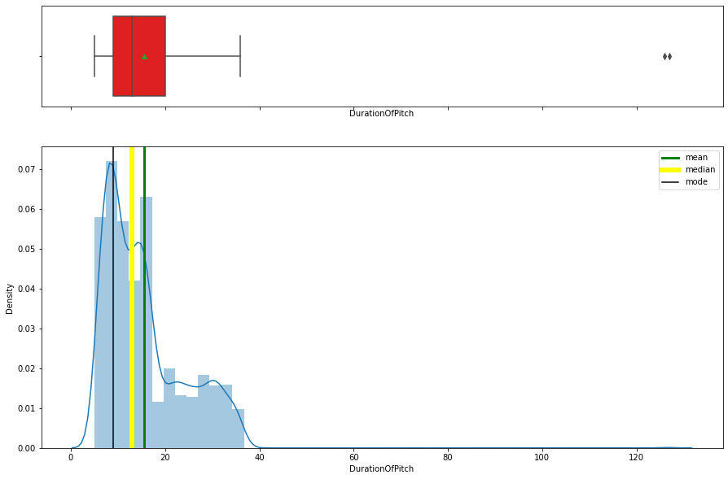

```python
histogram_boxplot(data.DurationOfPitch)
```

- DurationOfPitch feature is right-skewed.
- There are outliers to the right of the curve which may explain its skewness.

### Observation on NumberOfTrips

```
Mean:3.236520640269587
Median:3.0
Mode:2.0
```

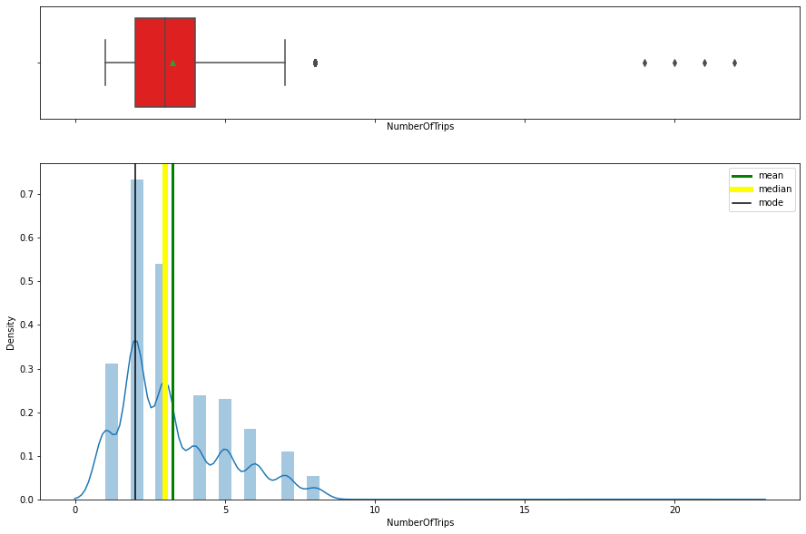

```python
histogram_boxplot(data.NumberOfTrips)
```

- NumberOfTrips feature is right-skewed.
- There are outliers to the right of the curve which may explain its skewness.

### Observation on MonthlyIncome

```
Mean:23619.85349087003
Median:22347.0
Mode:17342.0
```

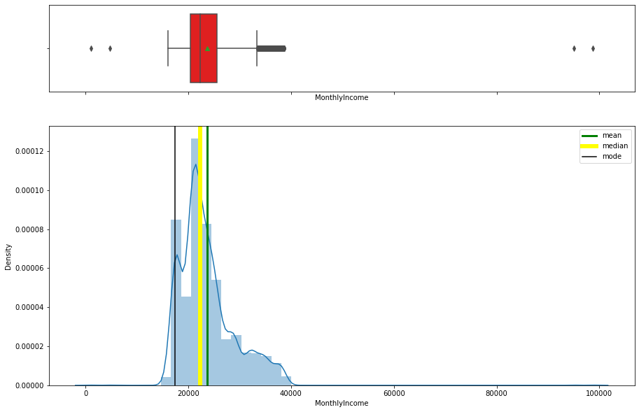

```python
histogram_boxplot(data.MonthlyIncome)
```

- MonthlyIncome feature is right-skewed.
- There are outliers to the right of the curve which may explain its skewness.

### Observations on ProdTaken (Dependant Variable)

```
ProdTaken
 0    0.811784
1    0.188216
Name: ProdTaken, dtype: float64

Top:0
Freq:3968
```

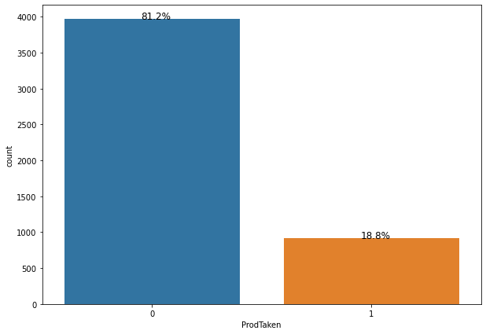

```python
print('ProdTaken\n' , data['ProdTaken'].value_counts(normalize=True) , '\n')
bar_count_pct(data.ProdTaken)
```

### Observations on Age

```
Age
 35.0    0.050837
36.0    0.049550
34.0    0.045260
31.0    0.043544
30.0    0.042686
32.0    0.042257
33.0    0.040541
37.0    0.039683
29.0    0.038181
38.0    0.037752
41.0    0.033248
39.0    0.032175
28.0    0.031532
40.0    0.031317
42.0    0.030459
27.0    0.029601
43.0    0.027885
46.0    0.025955
45.0    0.024882
26.0    0.022737
44.0    0.022523
51.0    0.019305
47.0    0.018876
50.0    0.018447
25.0    0.015873
52.0    0.014586
53.0    0.014157
48.0    0.013943
49.0    0.013943
55.0    0.013728
54.0    0.013085
56.0    0.012441
24.0    0.012012
23.0    0.009867
22.0    0.009867
59.0    0.009438
21.0    0.008795
20.0    0.008151
19.0    0.006864
58.0    0.006650
57.0    0.006221
60.0    0.006221
18.0    0.003003
61.0    0.001931
Name: Age, dtype: float64

Top:35.0
Freq:237
```

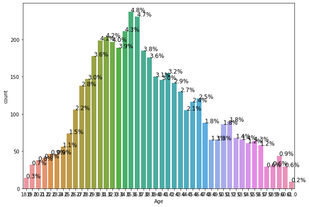

```python
print('Age\n' , data['Age'].value_counts(normalize=True) , '\n')
bar_count_pct(data.Age)
```

- Most common Age is 35, it has a frequency of 237.

### Observations on TypeofContact

```
TypeofContact
 Self Enquiry       0.708205
Company Invited    0.291795
Name: TypeofContact, dtype: float64

Top:Self Enquiry
Freq:3444
```

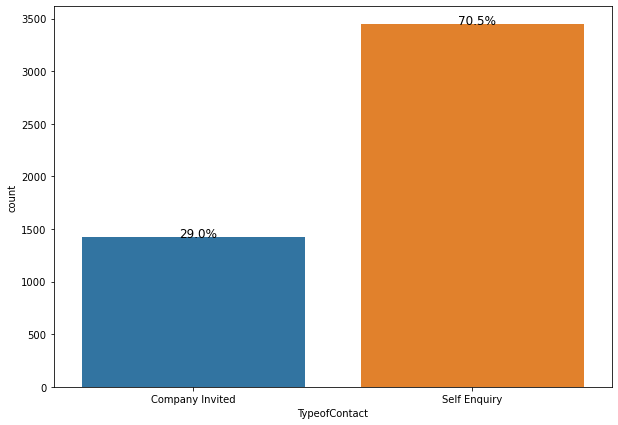

```python
print('TypeofContact\n' , data['TypeofContact'].value_counts(normalize=True) , '\n')
bar_count_pct(data.TypeofContact)
```

- Mode frequent TypeofContact is 'Self Enquiry' with 71%.
- Only 29% of have 'Company Invited'.
- There are 2 unique values.

### Observations on CityTier

```
CityTier
 1    0.652619
3    0.306874
2    0.040507
Name: CityTier, dtype: float64

Top:1
Freq:3190
```

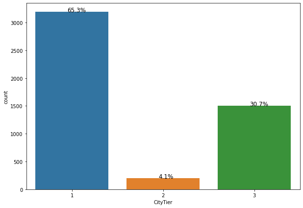

```python
print('CityTier\n' , data['CityTier'].value_counts(normalize=True) , '\n')
bar_count_pct(data.CityTier)
```

- Mode frequent CityTier is Tier-1 with 65%.
- Only 4.1% of are Tier-2.
- There are 3 unique values.

### Observations on Occupation

```
Occupation
 Salaried          0.484452
Small Business    0.426350
Large Business    0.088789
Free Lancer       0.000409
Name: Occupation, dtype: float64

Top:Salaried
Freq:2368
```

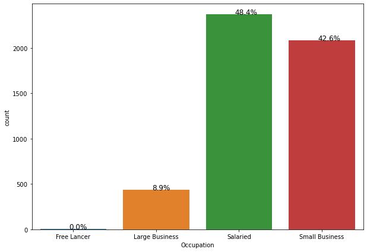

```python
print('Occupation\n' , data['Occupation'].value_counts(normalize=True) , '\n')
bar_count_pct(data.Occupation)
```

- Most frequent Occupation is Salaried with 48%.
- very few 0% are Free Lancer
- There are 4 unique values.

### Observations on Gender

```
Gender
 Male      0.596563
Female    0.403437
Name: Gender, dtype: float64

Top:Male
Freq:2916
```

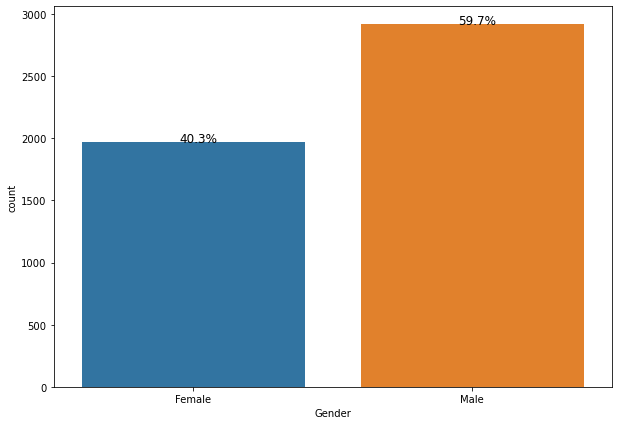

```python
print('Gender\n' , data['Gender'].value_counts(normalize=True) , '\n')
bar_count_pct(data.Gender)
```

- Most frequent Gender is Male with 60%.
- Female is 40%.
- There are 2 unique values.

### Observations on PreferredPropertyStar

```
PreferredPropertyStar
 3.0    0.615590
5.0    0.196627
4.0    0.187783
Name: PreferredPropertyStar, dtype: float64

Top:3.0
Freq:2993
```

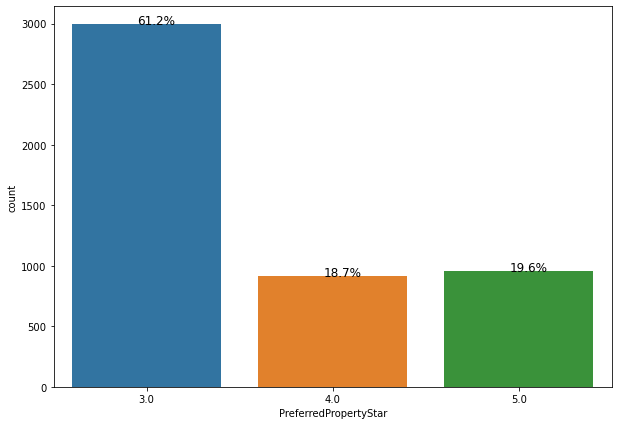

```python
print('PreferredPropertyStar\n' , data['PreferredPropertyStar'].value_counts(normalize=True) , '\n')
bar_count_pct(data.PreferredPropertyStar)
```

- Most frequent PreferredPropertyStar is 3 with 61%.
- 4 and 5 stars are pretty much even with 18% and 19% respectively.
- There are 3 unique values.

### Observations on ProductPitched

```
ProductPitched
 Basic           0.376841
Deluxe          0.354337
Standard        0.151800
Super Deluxe    0.069967
King            0.047054
Name: ProductPitched, dtype: float64

Top:Basic
Freq:1842
```

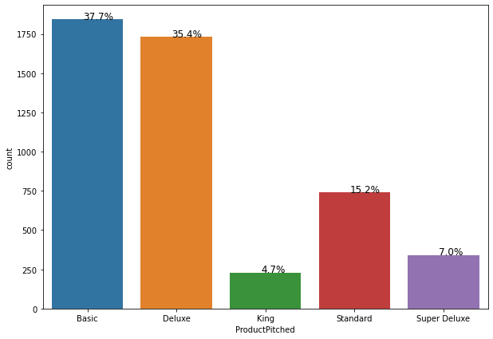

```python
print('ProductPitched\n' , data['ProductPitched'].value_counts(normalize=True) , '\n')
bar_count_pct(data.ProductPitched)
```

- Most frequent ProductPitched is Basic with 38%.
- King product is the lowest with 4.7%.
- There are 5 unique values.

### Observations on NumberOfPersonVisiting

```
NumberOfPersonVisiting
 3    0.491408
2    0.290098
4    0.209902
1    0.007979
5    0.000614
Name: NumberOfPersonVisiting, dtype: float64

Top:3
Freq:2402
```

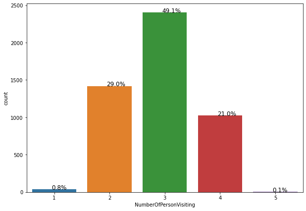

```python
print('NumberOfPersonVisiting\n' , data['NumberOfPersonVisiting'].value_counts(normalize=True) , '\n')
bar_count_pct(data.NumberOfPersonVisiting)
```

- Most frequent NumberOfPersonVisiting is 3 with 49%.
- 5 is the lowest with 0.1%.
- There are 5 unique values.

### Observations on NumberOfChildrenVisiting

```
NumberOfChildrenVisiting
 1.0    0.431356
2.0    0.276856
0.0    0.224388
3.0    0.067399
Name: NumberOfChildrenVisiting, dtype: float64

Top:1.0
Freq:2080
```

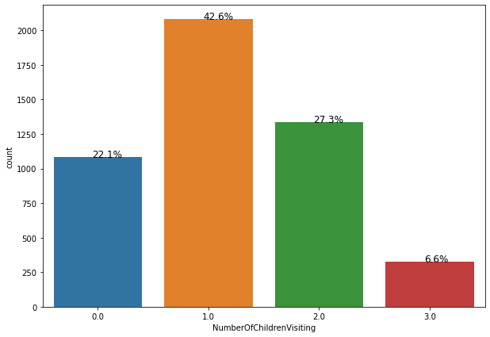

```python
print('NumberOfChildrenVisiting\n' , data['NumberOfChildrenVisiting'].value_counts(normalize=True) , '\n')
bar_count_pct(data.NumberOfChildrenVisiting)
```

- Most frequent NumberOfChildrenVisiting is 1 with 42%.
- 3 is the lowest with 6.6%.
- There are 4 unique values.

### Observations on NumberOfFollowups

```
NumberOfFollowups
 4.0    0.427008
3.0    0.302705
5.0    0.158579
2.0    0.047285
1.0    0.036341
6.0    0.028082
Name: NumberOfFollowups, dtype: float64

Top:4.0
Freq:2068
```

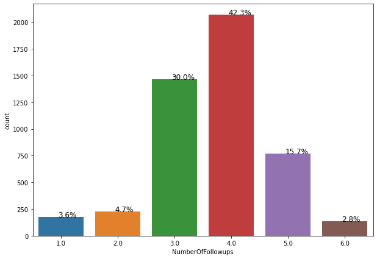

```python
print('NumberOfFollowups\n' , data['NumberOfFollowups'].value_counts(normalize=True) , '\n')
bar_count_pct(data.NumberOfFollowups)
```

- Most frequent NumberOfFollowups is 4 with 42%.
- 6 is the lowest with 2.8%.
- There are 6 unique values.

### Observations on MaritalStatus

```
MaritalStatus
 Married      0.478723
Divorced     0.194354
Single       0.187398
Unmarried    0.139525
Name: MaritalStatus, dtype: float64

Top:Married
Freq:2340
```

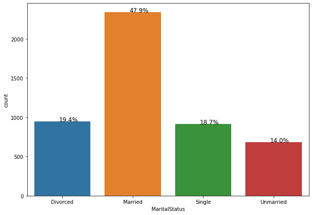

```python
print('MaritalStatus\n' , data['MaritalStatus'].value_counts(normalize=True) , '\n')
bar_count_pct(data.MaritalStatus)
```

- Most frequent MaritalStatus is Married with 48%.
- Unmarried is the lowest with 14%.
- There are 4 unique values.

### Observations on Designation

```
Designation
 Executive         0.376841
Manager           0.354337
Senior Manager    0.151800
AVP               0.069967
VP                0.047054
Name: Designation, dtype: float64

Top:Executive
Freq:1842
```

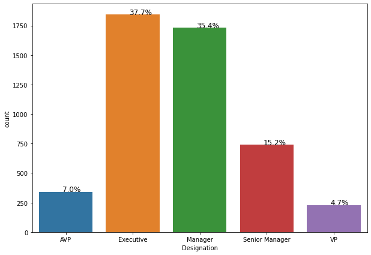

```python
print('Designation\n' , data['Designation'].value_counts(normalize=True) , '\n')
bar_count_pct(data.Designation)
```

- Most frequent Designation is Executive with 37%.
- VP is the lowest with 4.7%.
- There are 5 unique values.

### Observations on Passport

```
Passport
 0    0.709083
1    0.290917
Name: Passport, dtype: float64

Top:0
Freq:3466
```

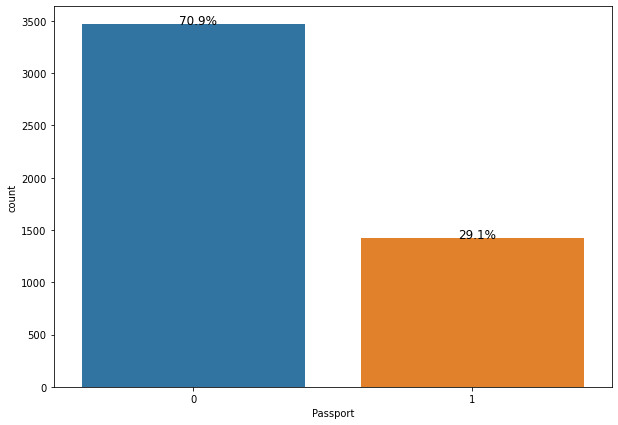

```python
print('Passport\n' , data['Passport'].value_counts(normalize=True) , '\n')
bar_count_pct(data.Passport)
```

- Most frequent Passport is False(0) with 71%.
- Passports True(1) is 29%.
- There are 2 unique values.

### Observations on PitchSatisfactionScore

```
PitchSatisfactionScore
 3    0.302373
5    0.198445
1    0.192717
4    0.186579
2    0.119885
Name: PitchSatisfactionScore, dtype: float64

Top:3
Freq:1478
```

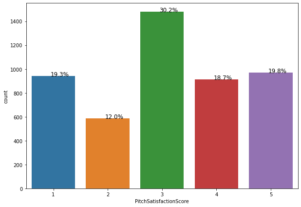

```python
print('PitchSatisfactionScore\n' , data['PitchSatisfactionScore'].value_counts(normalize=True) , '\n')
bar_count_pct(data.PitchSatisfactionScore)
```

- Most frequent PitchSatisfactionScore is 3 with 30%.
- PitchSatisfactionScore 2 is the lowest with 12%.
- There are 5 unique values.

### Observations on OwnCar

```
OwnCar
 1    0.620295
0    0.379705
Name: OwnCar, dtype: float64

Top:1
Freq:3032
```

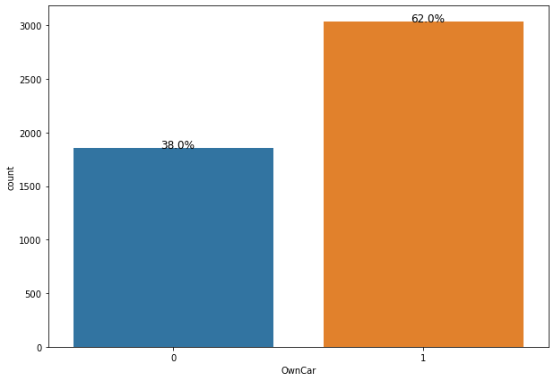

```python
print('OwnCar\n' , data['OwnCar'].value_counts(normalize=True) , '\n')
bar_count_pct(data.OwnCar)
```

- Most frequent OwnCar is True(1) with 62%.
- OwnCar False(0) is 38%.
- There are 2 unique values.

## Bivariate Analysis

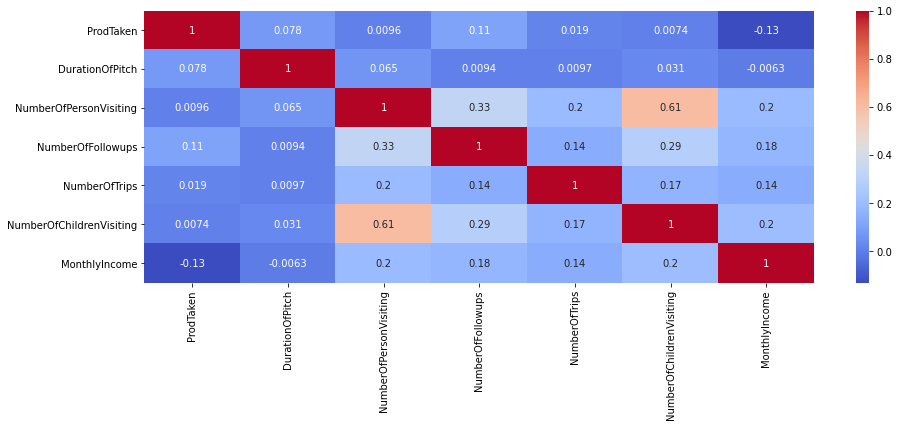

```python
plt.figure(figsize=(15,5))
sns.heatmap(data.corr(),annot=True, cmap="coolwarm")
plt.show()
```

### Bivariate analysis every possible attribute pair in relation to ProdTaken

```python
### Function to plot distributions and Boxplots of customers
def dist_catplot(x,target='ProdTaken'):
    fig,axs = plt.subplots(2,2,figsize=(12,10))
    axs[0, 0].set_title('Distribution of a customer who take the product')
    sns.distplot(data[(data[target] == 1)][x],ax=axs[0,0],color='teal')
    axs[0, 1].set_title("Distribution of a customer who doesn't take the product")
    sns.distplot(data[(data[target] == 0)][x],ax=axs[0,1],color='orange')
    axs[1,0].set_title('Boxplot with respect to ProdTaken')
    sns.boxplot(data[target],data[x],ax=axs[1,0],palette='gist_rainbow')
    axs[1,1].set_title('Boxplot with respect to ProdTaken - Without outliers')
    sns.boxplot(data[target],data[x],ax=axs[1,1],showfliers=False,palette='gist_rainbow')
    plt.tight_layout()
    plt.show()
```

```python
### Function to plot stacked bar charts for categorical columns
def stacked_plot(x):
    sns.set()
    ## crosstab
    tab1 = pd.crosstab(x,data['ProdTaken'],margins=True).sort_values(by=1,ascending=False)
    print(tab1)
    print('-'*120)
    ## visualising the cross tab
    tab = pd.crosstab(x,data['ProdTaken'],normalize='index').sort_values(by=1,ascending=False)
    tab.plot(kind='bar',stacked=True,figsize=(17,7))
    plt.legend(loc='lower left', frameon=False,)
    plt.legend(loc="upper left", bbox_to_anchor=(1,1))
    plt.show()
```

### Age vs ProdTaken

```
ProdTaken     0    1   All
Age
All        3786  876  4662
29.0        121   57   178
30.0        151   48   199
34.0        167   44   211
31.0        162   41   203
33.0        149   40   189
32.0        157   40   197
26.0         69   37   106
35.0        203   34   237
27.0        108   30   138
36.0        204   27   231
28.0        121   26   147
20.0         13   25    38
41.0        131   24   155
37.0        161   24   185
40.0        123   23   146
21.0         18   23    41
19.0         11   21    32
25.0         54   20    74
42.0        122   20   142
24.0         38   18    56
45.0         98   18   116
44.0         88   17   105
51.0         73   17    90
38.0        161   15   176
22.0         31   15    46
39.0        136   14   150
52.0         54   14    68
23.0         33   13    46
47.0         76   12    88
56.0         46   12    58
50.0         74   12    86
59.0         32   12    44
58.0         20   11    31
48.0         54   11    65
46.0        110   11   121
43.0        120   10   130
49.0         56    9    65
53.0         58    8    66
18.0          6    8    14
55.0         57    7    64
57.0         24    5    29
54.0         59    2    61
60.0         28    1    29
61.0          9    0     9
------------------------------------------------------------------------------------------------------------------------
```

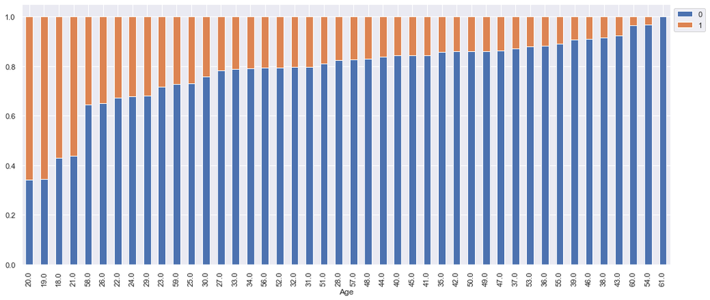

```python
stacked_plot(data['Age'])
```

- Propertianlally, There is significat difference in `Ages` 18-22 for customer that take the product is a higher success rate.

### TypeofContact vs Prod Taken

```
ProdTaken           0    1   All
TypeofContact
All              3946  917  4863
Self Enquiry     2837  607  3444
Company Invited  1109  310  1419
------------------------------------------------------------------------------------------------------------------------
```

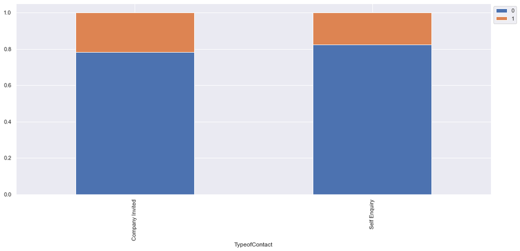

```python
stacked_plot(data['TypeofContact'])
```

- Proportionaly, there is no significat difference in `TypeofContact` for customer that take the product and those who do not.

### CityTier vs Prod Taken

```
ProdTaken     0    1   All
CityTier
All        3968  920  4888
1          2670  520  3190
3          1146  354  1500
2           152   46   198
------------------------------------------------------------------------------------------------------------------------
```

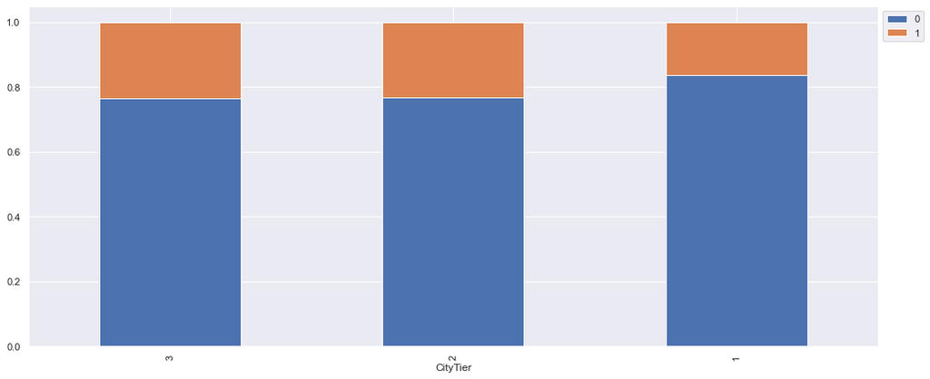

```python
stacked_plot(data['CityTier'])
```

- Proportionaly, there is no significat difference in `CityTier` for customer that take the product and those who do not.

### DurationOfPitch vs Prod Taken

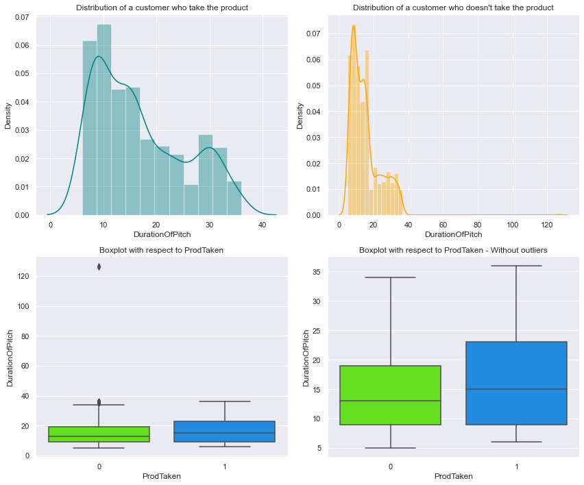

```python
dist_catplot('DurationOfPitch')
```

- When outliers are included in the comparison, there does not seem to be major difference in `Duration of Pitch` in regards to ProdTaken.
- When we remove outliers from the plot, we can see slight increase in ProdTaken when `DurationOfPitch` is higher than 20.

### Occupation vs Prod Taken

```
ProdTaken          0    1   All
Occupation
All             3968  920  4888
Salaried        1954  414  2368
Small Business  1700  384  2084
Large Business   314  120   434
Free Lancer        0    2     2
------------------------------------------------------------------------------------------------------------------------
```

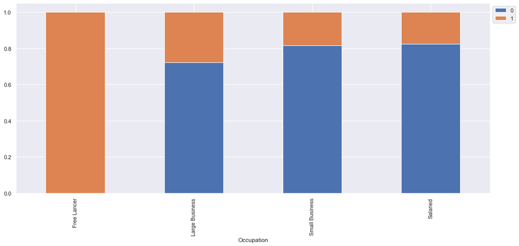

```python
stacked_plot(data['Occupation'])
```

### Gender vs Prod Taken

```
ProdTaken     0    1   All
Gender
All        3968  920  4888
Male       2338  578  2916
Female     1630  342  1972
------------------------------------------------------------------------------------------------------------------------
```

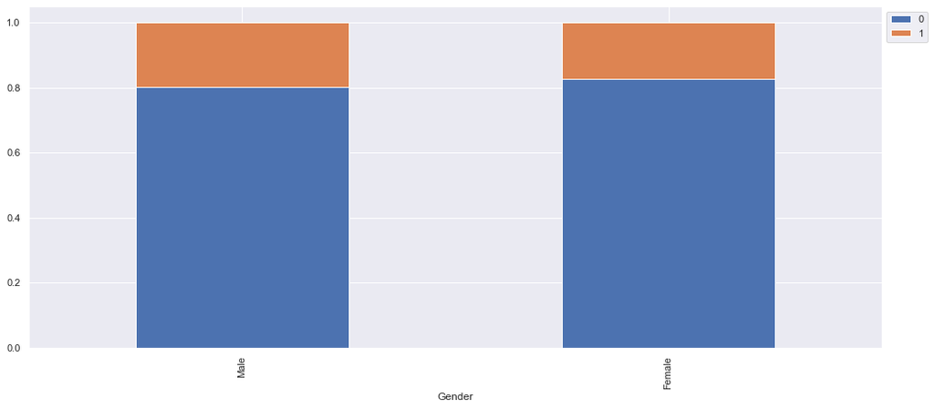

```python
stacked_plot(data['Gender'])
```

- Proportionaly, there is no significat difference in `Gender` for customer that take the product and those who do not.

### NumberOfPersonVisiting vs Prod Taken

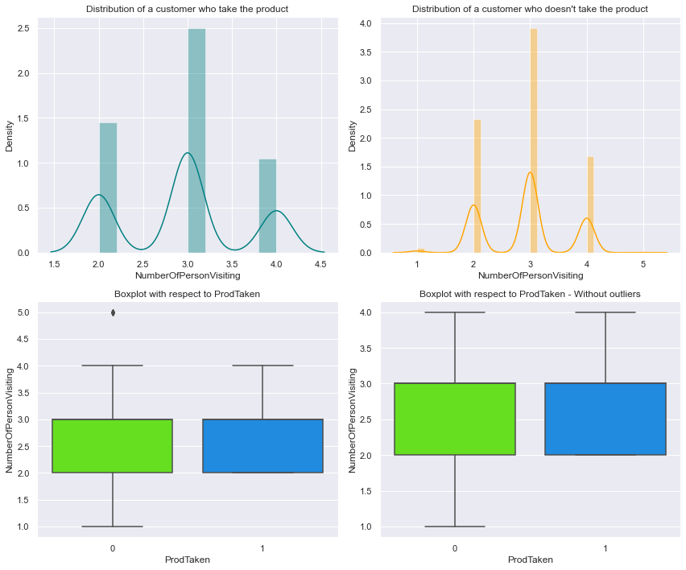

```python
dist_catplot('NumberOfPersonVisiting')
```

- There is no significant difference on `NumerOfPersonVisiting` when compared with or without outliers. In regards to ProdTaken.

### NumberOfFollowups vs Prod Taken

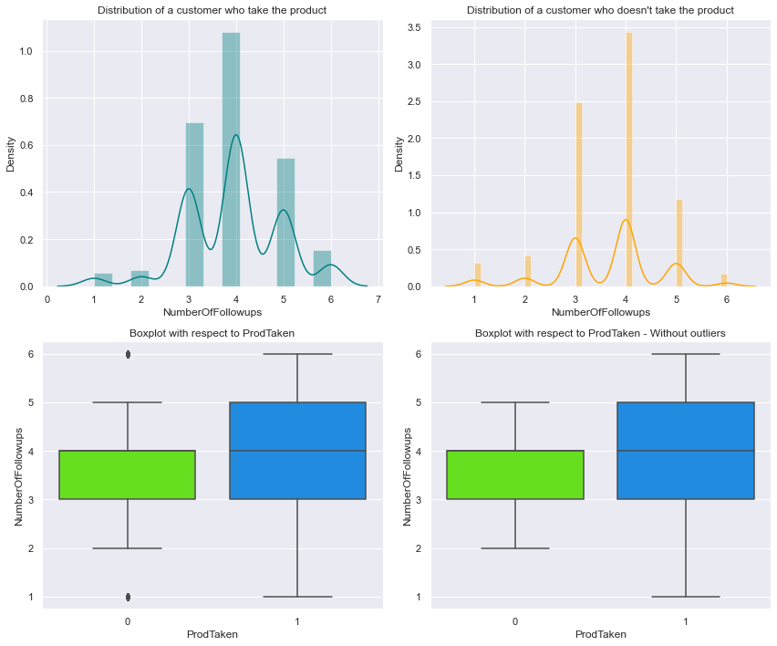

```python
dist_catplot('NumberOfFollowups')
```

- There is no significant difference on `NumberOfFollowups` when compared with or without outliers. In regards to ProdTaken.
- There is, however, an increase in ProdTaken in the ranges of 4-5 when compared to customer that did not ProdTaken.

### ProductPitched vs Prod Taken

```
ProdTaken          0    1   All
ProductPitched
All             3968  920  4888
Basic           1290  552  1842
Deluxe          1528  204  1732
Standard         618  124   742
King             210   20   230
Super Deluxe     322   20   342
------------------------------------------------------------------------------------------------------------------------
```

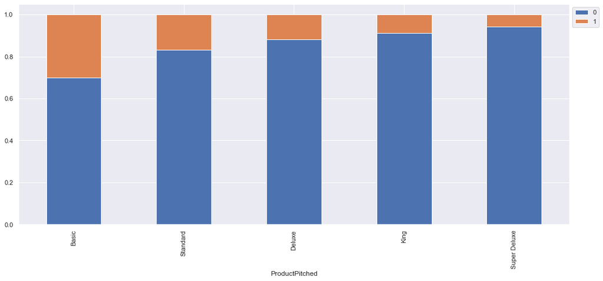

```python
stacked_plot(data['ProductPitched'])
```

- Proportionaly, there is a slight increase in `ProductPitched` Basic. This product is also the most pitched.

### PreferredPropertyStar vs Prod Taken

```
ProdTaken                 0    1   All
PreferredPropertyStar
All                    3948  914  4862
3.0                    2511  482  2993
5.0                     706  250   956
4.0                     731  182   913
------------------------------------------------------------------------------------------------------------------------
```

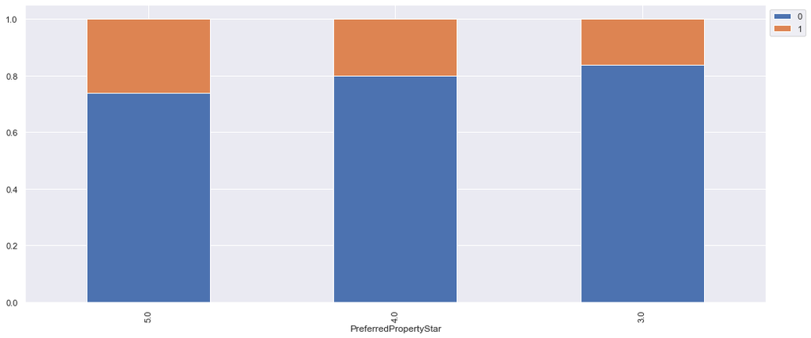

```python
stacked_plot(data['PreferredPropertyStar'])
```